# BRD-1748 Aneuploidy Exploration

Vickie

16 April, 2019

### CERS1 expression vs viability

We observe that high CERS1 expression is associated with sensitivity to BRD-1748. We use log2-transformed TPM and log2-transformed counts for CERS1 expression and log viability measures, respectively.

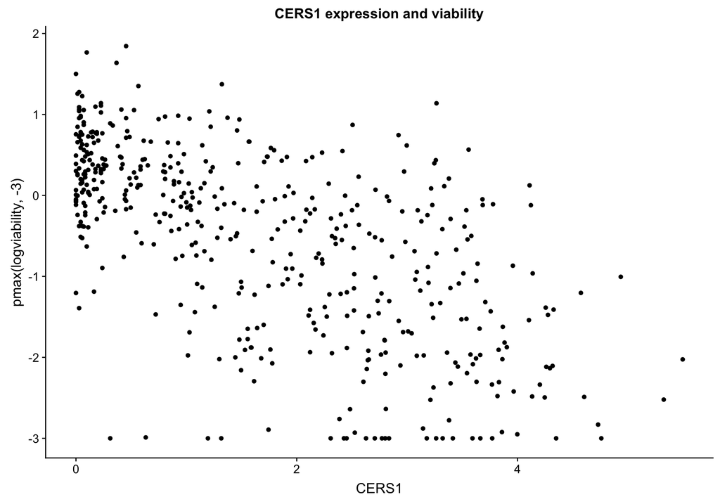

### Total aneuploidy vs viability

We examine the relationship between total aneuploidy and viability of cell lines. With all three aneuploidy metrics, there seems to be no significant correlation between total aneuploidy and viability.

#### Taylor/jul

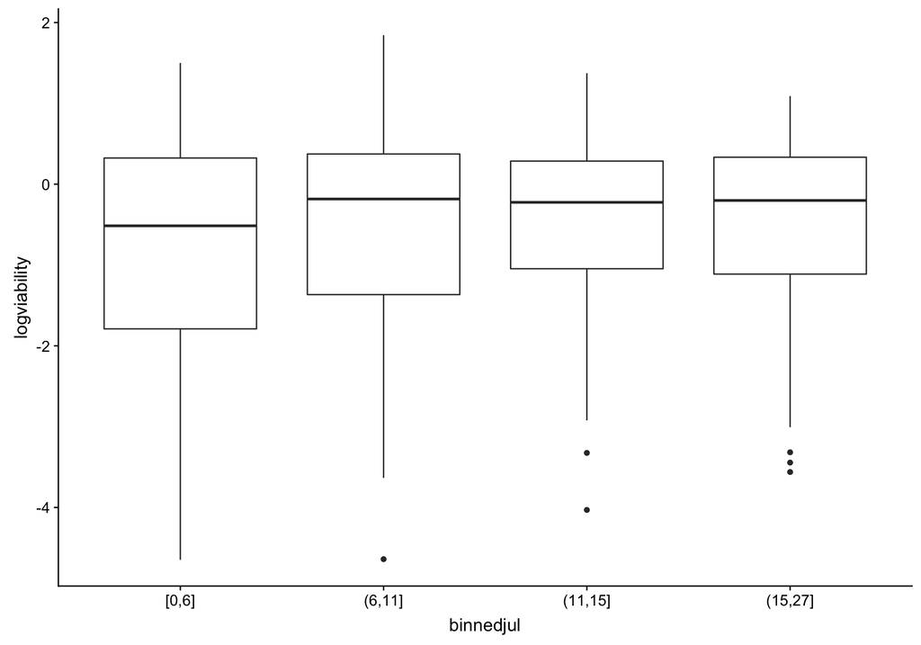

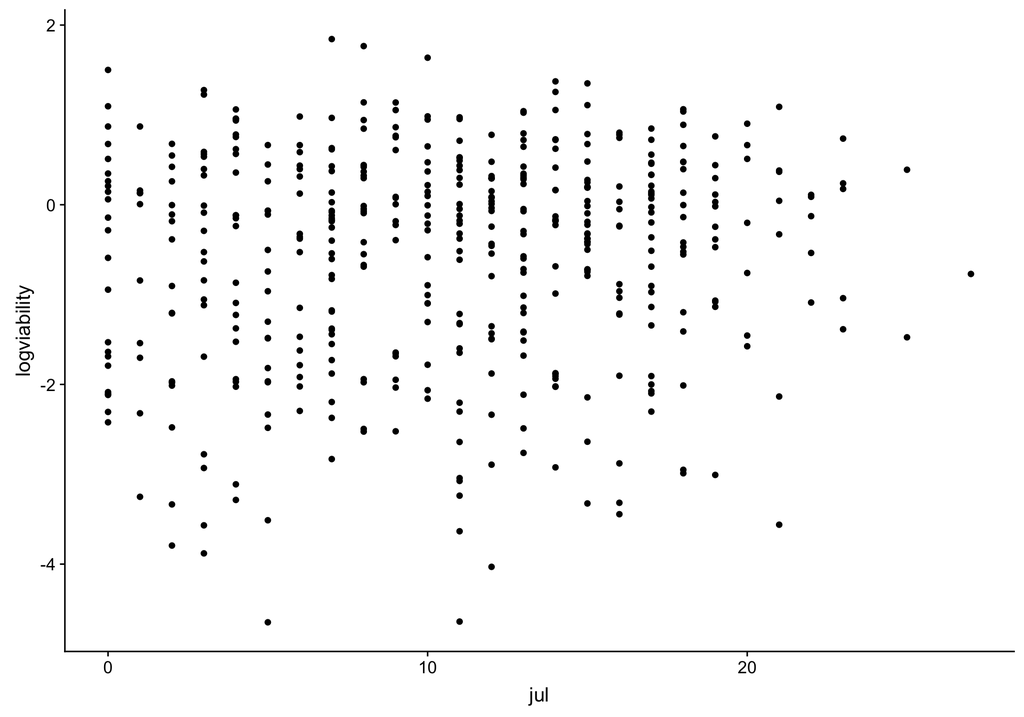

#### ABSOLUTE

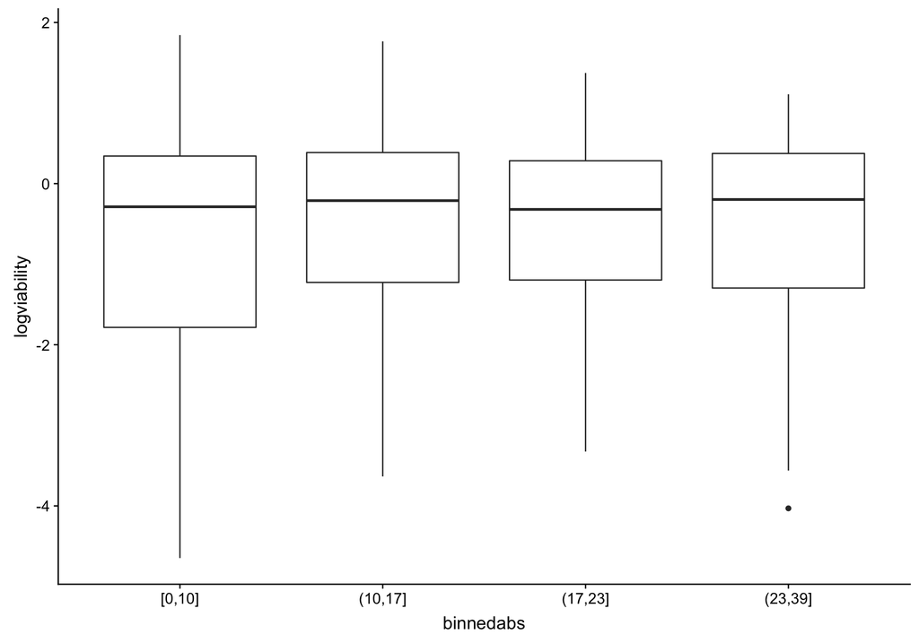

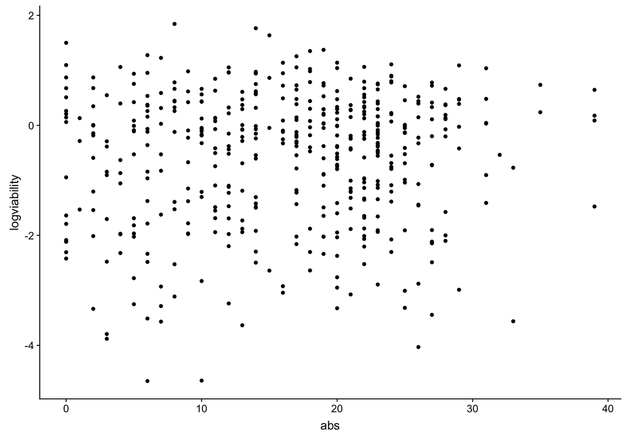

#### GISTIC

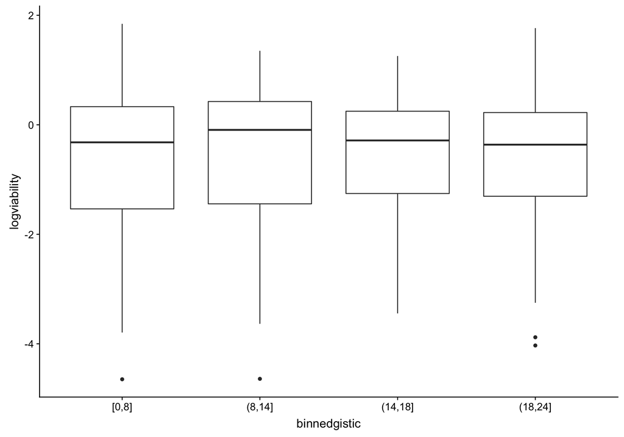

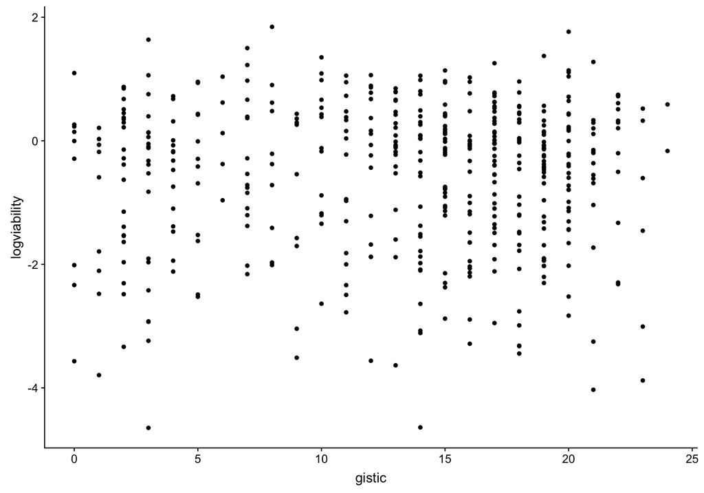

### 19p aneuploidy event

Since the CERS1 gene is found on chromosome 19p, we suspect there may be a relationship between 19p aneuploidy and cell line viability.

We first confirm that across 19p aneuploidy classes, the relationship between high CERS1 expression and sensitivity is intact.

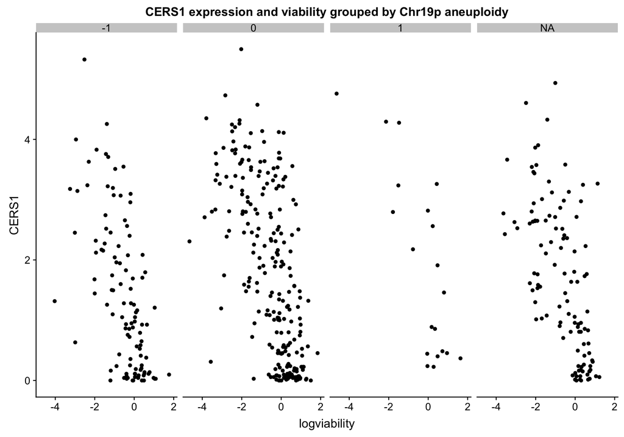

We examine the association of a 19p aneuploidy event on viability following treatment with BRD-1748. Surprisingly, a gain of 19p is associated with resistance. Viabilities of cell lines with loss of 19p are not significantly different than those with normal 19p.

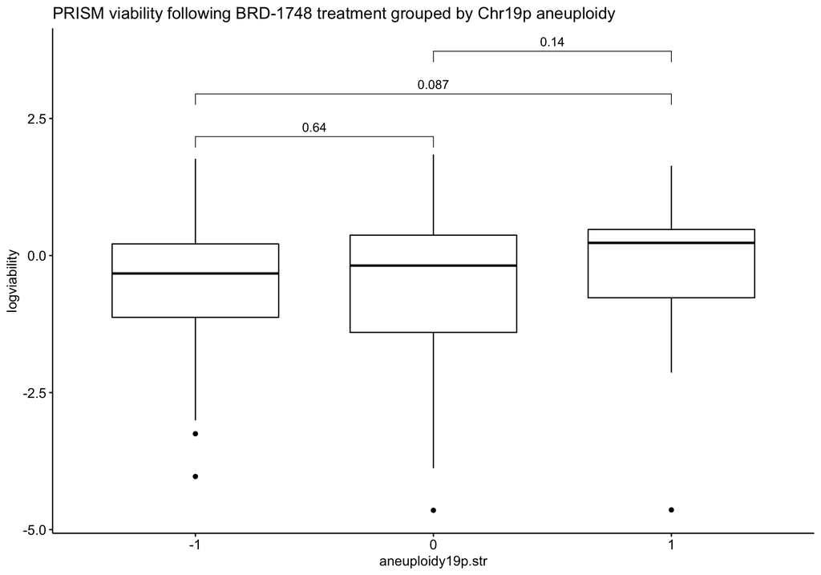

We also compare the differences in CERS1 expression across 19p aneuploidy events. It seems that cell lines with 19p loss have significantly lower CERS1 expression. However, a gain of 19p does not result in significantly higher expression.

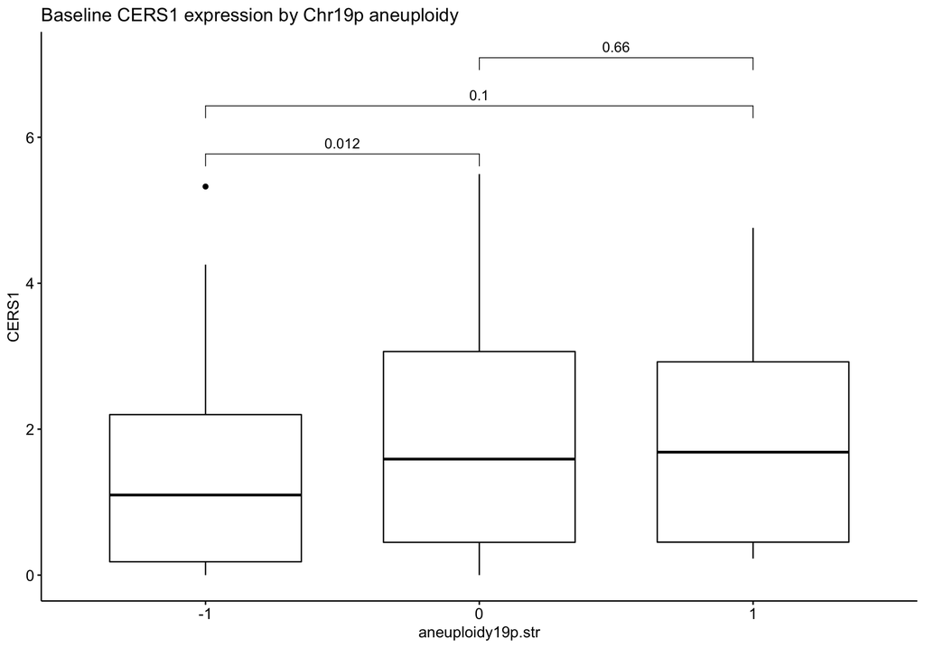

This leads us to hypothesize that there is something else in the 19p aneuploidy information, that is not captured solely by the CERS1 expression.

### Model comparison

We compare a linear model regressing log viability on CERS1 expression versus a linear model regressing log viability on CERS1 expression and 19p aneuploidy annotation.

Model 1:

```
##
## Call:
## lm(formula = logviability ~ CERS1, data = viab.aneu.19p.CERS1exp.noNA)
##
## Coefficients:
## (Intercept)        CERS1
##      0.3782      -0.5440
```

Model 2:

```
##
## Call:
## lm(formula = logviability ~ CERS1 + aneuploidy19p.num, data = viab.aneu.19p.CERS1exp.noNA)
##
## Coefficients:
##       (Intercept)              CERS1  aneuploidy19p.num
##            0.4567            -0.5563             0.2330
```

We find that including 19p aneuploidy annotations in the model yields a significant improvement over using just CERS1 expression (p-value = 0.0104).